# Homework #3

Michael Munguia

10/17/2021

```r
knitr::opts_chunk$set(echo = FALSE, warning = FALSE, message = FALSE)

library(tidyverse)
loans <- read_csv(
  "https://raw.githubusercontent.com/Izote/DATA622-Assignment-3/main/Loan_approval.csv", show_col_types = FALSE
  )

head(loans)
```

```
## # A tibble: 6 × 13
##   Loan_ID  Gender Married Dependents Education    Self_Employed ApplicantIncome
##   <chr>    <chr>  <chr>   <chr>      <chr>        <chr>                   <dbl>
## 1 LP001002 Male   No      0          Graduate     No                       5849
## 2 LP001003 Male   Yes     1          Graduate     No                       4583
## 3 LP001005 Male   Yes     0          Graduate     Yes                      3000
## 4 LP001006 Male   Yes     0          Not Graduate No                       2583
## 5 LP001008 Male   No      0          Graduate     No                       6000
## 6 LP001011 Male   Yes     2          Graduate     Yes                      5417
## # … with 6 more variables: CoapplicantIncome <dbl>, LoanAmount <dbl>,
## #   Loan_Amount_Term <dbl>, Credit_History <dbl>, Property_Area <chr>,
## #   Loan_Status <chr>
```

# Section 1: Exploratory Data Analysis (EDA)

Given that our target variable is an approved loan status ($Y$ value for $Loan_Status$), the very first observation we might make is that about 69% of the applicants represented in the data set were applicants with an approved loan. Surveying the continuous variables available, we see that applicant/co-applicants’ incomes and loan amounts share similarly right-skewed distributions, with the two income variables being more extreme in their skew. These three variables share a sense of scale (i.e. they refer to monetary amounts and two are incomes) whereas the loan term is on a different scale and measurement (months) along with its displaying a left-skewed distribution.

It is notable that the variable representing the income of a co-applicant, `CoapplicantIncome`, is an untidy variable - it represents both whether a co-applicant was involved in the process *and* their income. There is insufficient context to understand how to best utilize this variable. For example, a co-applicant may be a married spouse, blood relative or even a domestic partner. We may be able to intuit and better engineer features based on this information, but without further context we cannot know for certain how to handle unmarried applicants vis-a-vis their `CoapplicantIncome` value.

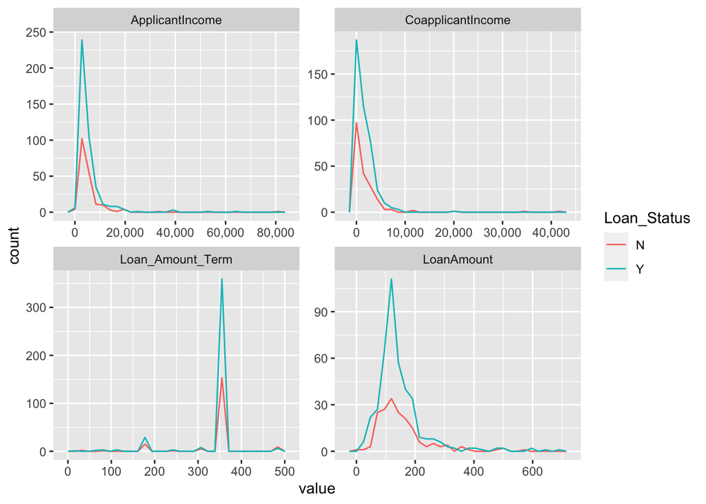

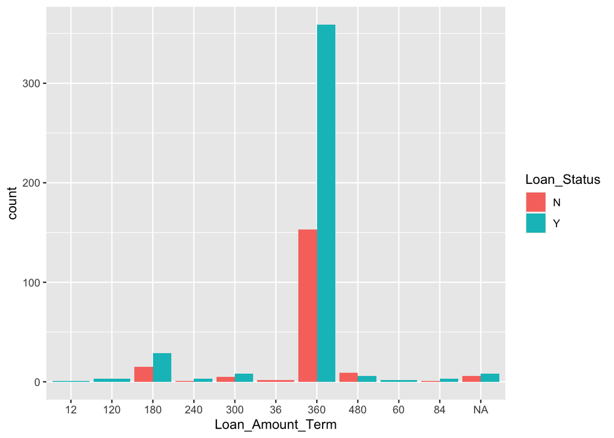

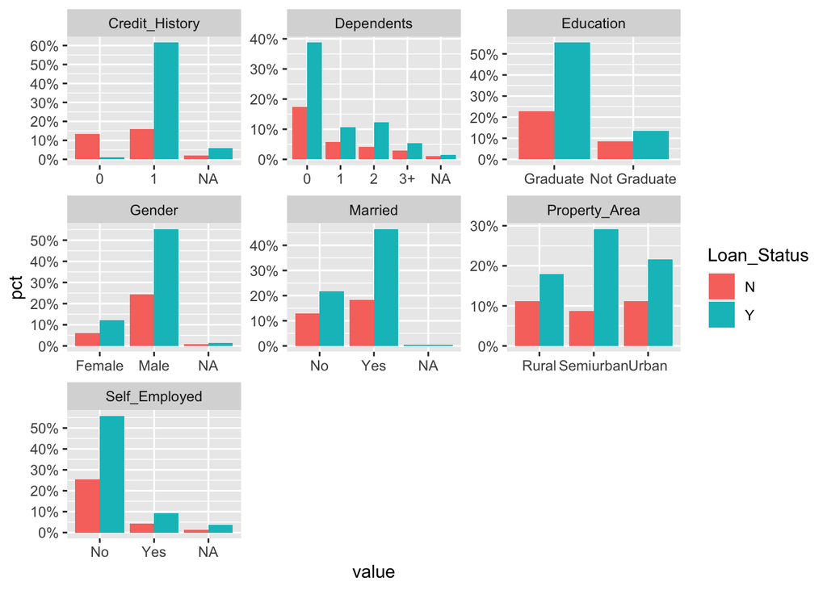

Married applicants make up a majority in both groups, though married applicants make up a greater portion of approved-loan applicants across the whole data set. In terms of sheer count, however, it should be noted there are nearly twice as many married applicants than single ones. While different types of property area are well represented across both groups, there is some differentiation in how they are represented within each group. The self-employed are less represented in the approved-loan group, though this may be an artifact of the lack of representation of many self-employed applicants to begin with - they make up only 13% of applicants (or a count of 82).